# Machine learning Course Project

Stanislav Dmitriev

## Exploring the data

Assuming we gave already downloaded the data, let’s load it…

```r
train_set <- read.csv("pml-training.csv")
test_set <- read.csv("pml-testing.csv")
```

… and study it’s structure…

```r
str(train_set)
summary(train_set)
glimpse(train_set)
```

[output not shown]

… and make some plots.

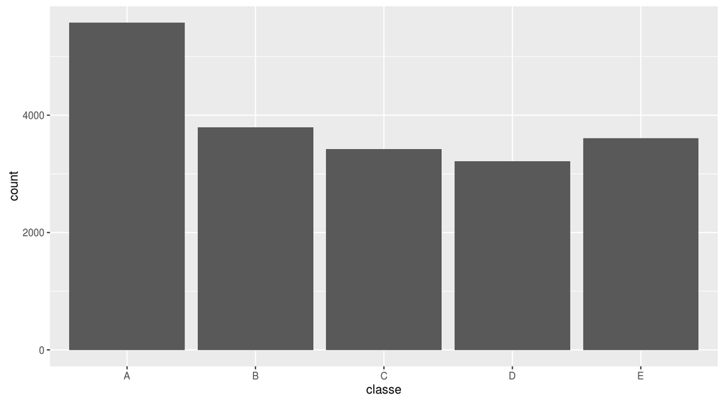

```r
ggplot(data = train_set, aes(x = classe)) + geom_bar()
```

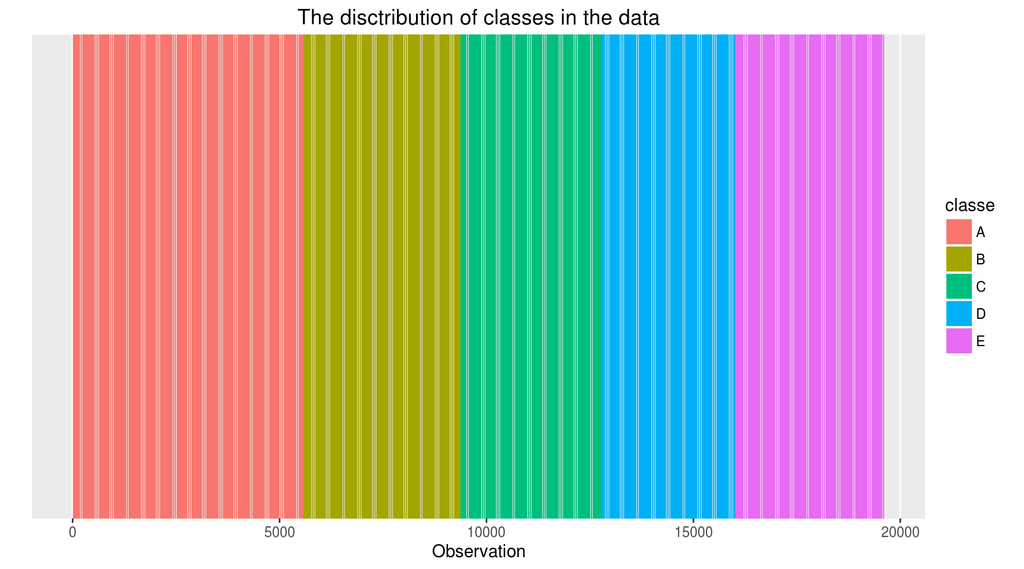

```r
ggplot(data = train_set, aes(x = 1:dim(train_set)[1], y = 1, fill=classe)) + geom_bar(stat="identity") +
  xlab("Observation") + ylab("")+ ggtitle("The disctribution of classes in the data") +
  scale_y_discrete()
```

We can notice at least 4 things:

1. NA are represented in three kind of ways (“NA”, “#DIV/0!”, “”).
2. There are a lot of NAs.
3. “A”" class is the most common.
4. Observations are grouped by classes.

Let’s reload the data, marking NAs.

```r
train_set <- read.csv("pml-training.csv", na.strings = c("NA", "#DIV/0!", ""))
test_set <- read.csv("pml-testing.csv", na.strings = c("NA", "#DIV/0!", ""))
```

And count the percentage of NAs in the columns.

```r
t <- train_set %>% summarize_each( funs (sum(is.na(.)) / length(.)) ) %>% extract(1,) %>% as.numeric() %>% round(2)
names(t) <- names(train_set)

table(t)
```

```
## t
##    0 0.98    1
##   60   94    6
```

We can easily remove columns with more then 90% of NAs. And columns with information irrelevant for our analysis.

```r
cols_to_delete <- names(t[t > 0.9])

more_cols_to_delete <- names(train_set[1,1:7])
united_to_delete <- c(cols_to_delete, more_cols_to_delete)
```

Let’s clear our data and create final data frame for analysis.

```r
clear_train_set <- select(train_set, -one_of(united_to_delete))
clear_test_set <- select(test_set, -one_of(united_to_delete))
```

## Selecting models for testing

I will use and compare 5 models mentions in the course:

1. Recursive partitioning (rpart)
2. Random forests (rf)
3. Bagged trees (treebag)
4. Boosted trees (gbm)
5. Linear discriminant analysis (lda)

## Control and validation

```r
set.seed(13)

my_split <- createDataPartition(train_set$classe, p = 0.8, list = F)

my_train <- clear_train_set[my_split,]
my_test <- clear_train_set[-my_split,]

tc <- trainControl(method = "cv", number = 10, verboseIter = T, allowParallel = T)
```

```r
cl <- makeCluster(detectCores() - 1)
registerDoParallel(cl)

model_rpart <- train(classe ~ ., method = "rpart", trControl = tc, data = my_train) # +
model_rf <- train(classe ~ ., method = "rf", data = my_train)
model_treebag <- train(classe ~ ., method = "treebag", trControl = tc, data = my_train) # +
model_gbm <- train(classe ~ ., method = "gbm", trControl = tc, data = my_train) # +
model_lda <- train(classe ~ ., method = "lda", trControl = tc, data = my_train) # +

stopCluster(cl)
```

Let’s see the accuracy of our models.

```r
models <- c(
          model_rpart$method,
          model_rf$method,
          model_treebag$method,
          model_gbm$method,
          model_lda$method
          )

accuracy <- c(
            max(model_rpart$results$Accuracy),
            max(model_rf$results$Accuracy),
            max(model_treebag$results$Accuracy),
            max(model_gbm$results$Accuracy),
            max(model_lda$results$Accuracy)
            )

ac <- data.frame(models, accuracy) %>% arrange(desc(accuracy))

ac
```

```
##    models  accuracy
## 1      rf 0.9833733
## 2 treebag 0.9780887
## 3     gbm 0.9568888
## 4     lda 0.7057675
## 5   rpart 0.5081557
```

It seems that Random forests, Bagged trees and Boosted trees show exellent results on training set. Let’s test then on the testing set.

```r
pr_model_rf <- predict(model_rf, newdata = my_test)
pr_model_treebag <- predict(model_treebag, newdata = my_test)
pr_model_gbm <- predict(model_gbm, newdata = my_test)

cf_rf <- confusionMatrix(pr_model_rf, my_test$classe)
cf_rf$table
```

```
##           Reference
## Prediction    A    B    C    D    E
##          A 1115    6    0    0    0
##          B    0  751    4    0    0
##          C    0    2  680    5    1
##          D    1    0    0  638    0
##          E    0    0    0    0  720
```

```r
cf_rf$overall
```

```
##       Accuracy          Kappa  AccuracyLower  AccuracyUpper   AccuracyNull
##      0.9951568      0.9938730      0.9924470      0.9970816      0.2844762
## AccuracyPValue  McnemarPValue
##      0.0000000            NaN
```

```r
cf_treebag <- confusionMatrix(pr_model_treebag, my_test$classe)
cf_treebag$table
```

```
##           Reference
## Prediction    A    B    C    D    E
##          A 1114    5    0    0    0
##          B    0  749    5    0    2
##          C    2    4  673   11    3
##          D    0    1    4  631    1
##          E    0    0    2    1  715
```

```r
cf_treebag$overall
```

```
##       Accuracy          Kappa  AccuracyLower  AccuracyUpper   AccuracyNull
##      0.9895488      0.9867793      0.9858482      0.9924899      0.2844762
## AccuracyPValue  McnemarPValue
##      0.0000000            NaN
```

```r
cf_gbm <- confusionMatrix(pr_model_gbm, my_test$classe)
cf_gbm$table
```

```
##           Reference
## Prediction    A    B    C    D    E
##          A 1101   18    0    0    0
##          B   11  723   18    2    9
##          C    3   17  656   17    5
##          D    1    1   10  620    6
##          E    0    0    0    4  701
```

```r
cf_gbm$overall
```

```
##       Accuracy          Kappa  AccuracyLower  AccuracyUpper   AccuracyNull
##      0.9689014      0.9606605      0.9629808      0.9741090      0.2844762
## AccuracyPValue  McnemarPValue
##      0.0000000            NaN
```

## Final model and estimation of error rate

```r
final_rediction <- predict(model_rf, newdata = clear_test_set)
num <- 1:20
data.frame(num, final_rediction)
```

```
##    num final_rediction
## 1    1               B
## 2    2               A
## 3    3               B
## 4    4               A
## 5    5               A
## 6    6               E
## 7    7               D
## 8    8               B
## 9    9               A
## 10  10               A
## 11  11               B
## 12  12               C
## 13  13               B
## 14  14               A
## 15  15               E
## 16  16               E
## 17  17               A
## 18  18               B
## 19  19               B
## 20  20               B
```